# Data Dive Intro Slides

23. Oktober 2015

## The DataAnimals

**Welcome to the Berlin Data Dive**

In the next slides you will get to know us and learn something about the dataset we have compiled for you. For further questions, feel free to approach one of the present animals at any time during the event.

## Who are we?

We are a group of Berlin-based Master students with a strong background in data analysis and statistics.

We are a non-profit with no business interests. Our motivation is to further develop ourselves and our skills beyond textbooks and theories.

## What do we try to do after the dive?

- Workshops for R, Stata, and Excel
- Data Analysis for non-profits
- Kaggle

Want to know more?

Browse http://data-animals.eu,

or find http://facebook.com/dataanimals.

## Dataset

The datasets are merged from four different sources (description of these sources in Hackpad).

They include the - Individual student's names and grades of their school leaving examinations (2013 - 2014) - Information about their schools (2011 - 2014) - Internal Jambo Bukoba data (2010 - 2015)

## Dataset

Three formats: (1) Student level, (2) School level, (3) Time Series

With (2) and (3) being transformations of (1).

With (1) being most comprehensive.

Which one to use? Depends on your research ideas. Remember: you can easily transform the data yourself.

## Dataset format 1 - Student level

The (1) student levlel (most comprehensive) dataset we compiled contains **91** variables and **141368** observation in total.

It is cross-sectional data, the unit being the student. Thus, there are **141368** students who passed their school leaving examinations in 2013 and 2014 in the data, who visited **1570** different schools.

## Dataset format 2 - School level

A reduced version of the student level data.

Individual student data is dropped.

Each school in one row, Jambo Bukoba's data is bound right.

## Dataset format 3 - Time series

School level data as time series.

Each school has one row pear year (2010 to 2015).

School data and Jambo Bukoba is bound right.

## Pie charts schools reached overall

In total 31% have at least one teacher who visited a workshop.

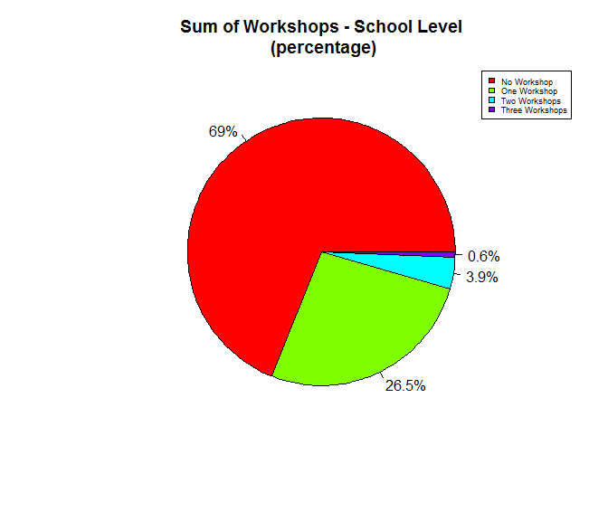

Range from 0 to 250

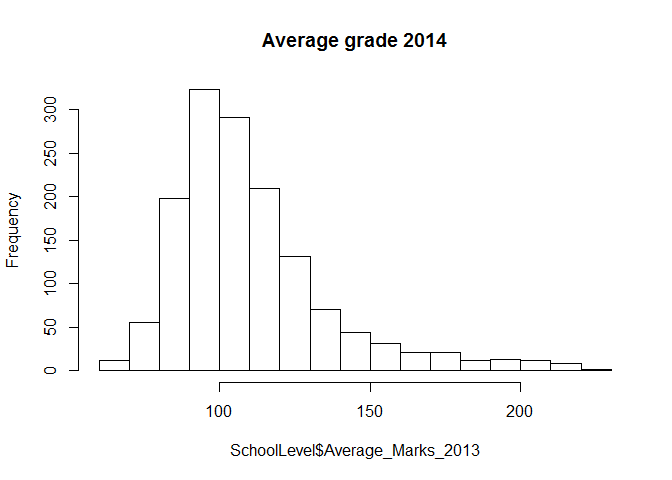

## Students' grades Englisch

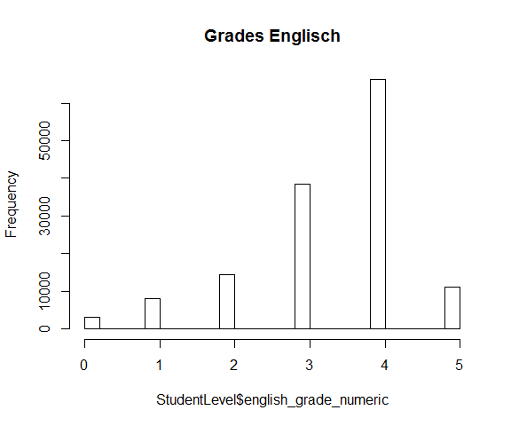

## Gender ratio 1

Proportion of male and female students, 2013 and 2014

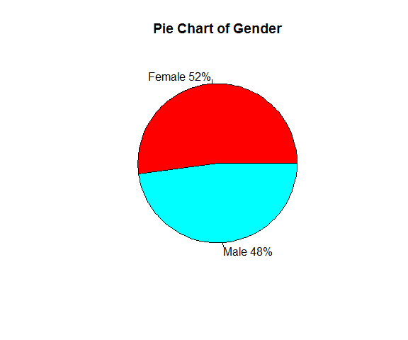

## Gender ratio 2

Proportion of male and female students per class 2013/14

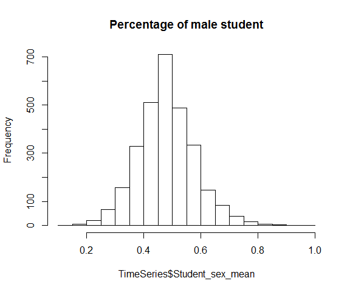

## Warm-up questions

Do you want to familiarize yourself with datasets? Here are simple warm up tasks for you:

1. How many School projects are in the dataset? What were the activities?
2. How many schools have more female than male students?
3. How many students did participate in workshops in 2014?
4. Are grades normally distributed?
5. Are boys better in maths and girls better in Swahili?

## Links

[Data on Google Drive](https://drive.google.com/drive/folders/0B3aFaGPDtkwdZ1ZGMnV4N2g4dUk)

[Data on GitHub](https://github.com/ChristopherCosler/DataJamboBukoba)

[Codebooks](https://drive.google.com/folderview?id=0B3X17L5ZOPajX1Q5OU5OMHdSbkE&usp=sharing)

[Hackpad!](https://hackpad.com/Jambo-Bukoba-Dataset-gTEZotNwLQr)

## Have fun

www.data-animals.eu

Happy Diving!